# Проект 3: Исследование рынка недвижимости Санкт-Петербурга и городов-спутников

## Привет!

Я - Сергей. Рад что ты читаешь это текст :) Сделаю пару ремарок общего характера. В описании выполняемых действий, комментариях, я использую местоимение 'мы', так как считаю что ты, читая код, становиться моим соучастником ('соучавствующие программирование') и мы вместе проходим по пути исследования. Да и сформировлась привычка так писать в ходе написания научных работ. NB! - так помечаю важные на мой взгдял идеи, которые стоит взять на заметку; инсайты, проработка которых требует большего знания предметной области. Надеюсь мои многословные комментарии тебя не утомят.

# Исследование объявлений о продаже квартир

В вашем распоряжении данные сервиса Яндекc Недвижимость — архив объявлений о продаже квартир в Санкт-Петербурге и соседних населённых пунктах за несколько лет. Нужно научиться определять рыночную стоимость объектов недвижимости. Ваша задача — установить параметры. Это позволит построить автоматизированную систему: она отследит аномалии и мошенническую деятельность.

По каждой квартире на продажу доступны два вида данных. Первые вписаны пользователем, вторые получены автоматически на основе картографических данных. Например, расстояние до центра, аэропорта, ближайшего парка и водоёма.

**Описание данных:**  
airports_nearest — расстояние до ближайшего аэропорта в метрах (м)  
balcony — число балконов  
ceiling_height — высота потолков (м)  
cityCenters_nearest — расстояние до центра города (м)  
days_exposition — сколько дней было размещено объявление (от публикации до снятия)  
first_day_exposition — дата публикации  
floor — этаж  
floors_total — всего этажей в доме  
is_apartment — апартаменты (булев тип)  
kitchen_area — площадь кухни в квадратных метрах (м²)  
last_price — цена на момент снятия с публикации  
living_area — жилая площадь в квадратных метрах (м²)  
locality_name — название населённого пункта  
open_plan — свободная планировка (булев тип)  
parks_around3000 — число парков в радиусе 3 км  
parks_nearest — расстояние до ближайшего парка (м)  
ponds_around3000 — число водоёмов в радиусе 3 км  
ponds_nearest — расстояние до ближайшего водоёма (м)  
rooms — число комнат  
studio — квартира-студия (булев тип)  
total_area — площадь квартиры в квадратных метрах (м²)  
total_images — число фотографий квартиры в объявлении  
Пояснение: апартаменты — это нежилые помещения, которые не относятся к жилому фонду, но имеют необходимые условия для проживания.

## Изучение данных из файла

```python
#импортируем необходимые библиотеки
import pandas as pd
import numpy as np
import matplotlib.pyplot as plt
%matplotlib inline
import seaborn as sns
from datetime import datetime  # для получения дня недели из даты
```

```python
# Прочитаем файл с гугл диска
from io import BytesIO
import requests
spreadsheet_id = '1drh47tUF_gRpwiFkryuRB5Ho-rIIV-S69qwkYm0OY50'
file_name = 'https://docs.google.com/spreadsheets/d/{}/export?format=csv'.format(spreadsheet_id)
r = requests.get(file_name)
data = pd.read_csv(BytesIO(r.content))
#разделены слешем (\)
pd.set_option('display.max_columns', 30)
display(data)
```

|  | total_images | last_price | total_area | first_day_exposition | rooms | ceiling_height | floors_total | living_area | floor | is_apartment | studio | open_plan | kitchen_area | balcony | locality_name | airports_nearest | cityCenters_nearest | parks_around3000 | parks_nearest | ponds_around3000 | ponds_nearest | days_exposition |
| --- | --- | --- | --- | --- | --- | --- | --- | --- | --- | --- | --- | --- | --- | --- | --- | --- | --- | --- | --- | --- | --- | --- |
| 0 | 20 | 13000000.0 | 108.00 | 2019-03-07 0:00:00 | 3 | 2.70 | 16.0 | 51.0 | 8 | NaN | False | False | 25.00 | NaN | Санкт-Петербург | 18863.0 | 16028.0 | 1.0 | 482.0 | 2.0 | 755.0 | NaN |
| 1 | 7 | 3350000.0 | 40.40 | 2018-12-04 0:00:00 | 1 | NaN | 11.0 | 18.6 | 1 | NaN | False | False | 11.00 | 2.0 | посёлок Шушары | 12817.0 | 18603.0 | 0.0 | NaN | 0.0 | NaN | 81.0 |
| 2 | 10 | 5196000.0 | 56.00 | 2015-08-20 0:00:00 | 2 | NaN | 5.0 | 34.3 | 4 | NaN | False | False | 8.30 | 0.0 | Санкт-Петербург | 21741.0 | 13933.0 | 1.0 | 90.0 | 2.0 | 574.0 | 558.0 |
| 3 | 0 | 64900000.0 | 159.00 | 2015-07-24 0:00:00 | 3 | NaN | 14.0 | NaN | 9 | NaN | False | False | NaN | 0.0 | Санкт-Петербург | 28098.0 | 6800.0 | 2.0 | 84.0 | 3.0 | 234.0 | 424.0 |
| 4 | 2 | 10000000.0 | 100.00 | 2018-06-19 0:00:00 | 2 | 3.03 | 14.0 | 32.0 | 13 | NaN | False | False | 41.00 | NaN | Санкт-Петербург | 31856.0 | 8098.0 | 2.0 | 112.0 | 1.0 | 48.0 | 121.0 |
| ... | ... | ... | ... | ... | ... | ... | ... | ... | ... | ... | ... | ... | ... | ... | ... | ... | ... | ... | ... | ... | ... | ... |
| 23694 | 9 | 9700000.0 | 133.81 | 2017-03-21 0:00:00 | 3 | 3.70 | 5.0 | 73.3 | 3 | NaN | False | False | 13.83 | NaN | Санкт-Петербург | 24665.0 | 4232.0 | 1.0 | 796.0 | 3.0 | 381.0 | NaN |
| 23695 | 14 | 3100000.0 | 59.00 | 2018-01-15 0:00:00 | 3 | NaN | 5.0 | 38.0 | 4 | NaN | False | False | 8.50 | NaN | Тосно | NaN | NaN | NaN | NaN | NaN | NaN | 45.0 |
| 23696 | 18 | 2500000.0 | 56.70 | 2018-02-11 0:00:00 | 2 | NaN | 3.0 | 29.7 | 1 | NaN | False | False | NaN | NaN | село Рождествено | NaN | NaN | NaN | NaN | NaN | NaN | NaN |
| 23697 | 13 | 11475000.0 | 76.75 | 2017-03-28 0:00:00 | 2 | 3.00 | 17.0 | NaN | 12 | NaN | False | False | 23.30 | 2.0 | Санкт-Петербург | 39140.0 | 10364.0 | 2.0 | 173.0 | 3.0 | 196.0 | 602.0 |
| 23698 | 4 | 1350000.0 | 32.30 | 2017-07-21 0:00:00 | 1 | 2.50 | 5.0 | 12.3 | 1 | NaN | False | False | 9.00 | NaN | поселок Новый Учхоз | NaN | NaN | NaN | NaN | NaN | NaN | NaN |

23699 rows × 22 columns

### Вывод

1. В датафрейме 23699 строк (наблюдений) и 22 колонки.
2. Датафрейм собержит значения следующих типов: логические (bool) - 2 колонки, числа с дробной частью (float64) - 14 колонок, целые числа (int64) - 3 колонки, объекты (object) -3 колонки, содержащие значения даты и времени, текстовые значения.
3. В колонках ceiling_height, floors_total, living_area, is_apartment, kitchen_area, balcony, locality_name, airports_nearest, cityCenters_nearest, parks_around3000, parks_nearest, ponds_around3000, ponds_nearest, days_exposition есть пропущенные значения.
4. В колонке is_apartment должны содержаться булиевы значения, но ей тип object, а не bool. В колонке также есть пропуски.
5. Название колонки cityCenters_nearest выполнено не в "змеином" стиле - его можно переименовать в рамках хорошего тона, например на city_centers_nearest.

## Предобработка данных

```python
# Переименуем колонку cityCenters_nearest в соответсвии с правилами хорошего тона
data.rename(columns={'cityCenters_nearest': 'city_centers_nearest'}, inplace=True)
#data.info()
```

### Обработка пропущенных значений

**Возможные причины пропусков значений и что будем делать с ними:**

1. **ceiling_height** - высота потолков - люди, размещающие объявления могут не знать её, им не хочется измерять, считают что это не важный параметр.**Гипотеза:** высота потолков может коррелировать с местонахождением дома: центр СПб - старый фонд с высокими потолками, средний пояс - хрущёвки, окрайны - новостроки, и те и другие с низкими потолками.
2. **floors_total** - этажность дома - данные могут отсутствать по причине необязательности заполнения параметра. Учитывая, что этажность здания могут коррелирует с местонахождением здания (центр СПб - старый фонд с высокими потолками, средний пояс - хрущёвки, окрайны - новостроки, и те и другие с низкими потолками), заполним эти данные в соответствии с этой логикой.
3. **living_area** - жилая площадь - данные могут отсутствать по причине необязательности заполнения параметра.
4. **kitchen_are**a - площадь кухни - данные могут отсутствать по причине необязательности заполнения параметра. **Гипотеза:** выясним, нет ли такой связи, что если квартира - студия, то там отсутствуют эти данные. Ведь в них нет явного деления площади на ту, которая относится к кухне, и ту, которая относится к жилой площади.
5. **is_apartment** - апартаменты - люди могут не понимать разницы между квартирой и апартаметами. Данные могут отсутствать по причине необязательности заполнения параметра.
6. **balcony** - наличие балкона - вполне возможно, что где балкон отсутствует, там вместо 0 стоит NaN. Необходимо проверить, действительно ли по столбцу balcony присутствует только значение "1", говорящее, что балкон есть, а "0" - отсутствует.
7. **locality_name** - населенный пункт - выглядит довольно странно, когда не указывают населенный пункт. Предположу, что свойственно это тем продавцам, которые уверены, что всем очевидно, что если они выставляют квартиру на продажу в разделе сайта "Санкт-Петербург", то и квартира в Санкт-Петербурге, не подозревая даже, что это может быть и область. Тем не менее, заполним данные только по тем строкам, где указано расстояние до центра. **Гипотеза:** от центра до кольцевой автодороги (КАД) максимум 18 км (на севере города), квартиры, которые находятся в пределах **18** км от центра (измерил по Яндекс.Картам), получат Санкт-Петерубург вместо пропусков.
8. **airports_nearest** - расстояние до аэропорта, и cityCenters_nearest - расстояние до центра города - ПОКА НЕ ЗНАЮ
9. **parks_around3000, parks_nearest, ponds_around3000, ponds_nearest** - наличие и рассоние до ближаших парков и прудов. Данные могут отсутствать по причине необязательности заполнения параметра. Пропуски не повлияют на анализ.
10. **days_exposition** - число дней показа объявления -важный параметр, пропуски могут быть связаны с техническими сбоями, обявление не сняли с публикации и оно ообнулилось через какой-то срок. Но заполнить его средним или медианным значем нет смысла. Не будем заполнять пропуски.

Пойдём по порядку по колонкам с пропущенными значениями

#### locality_name

```python
#Посмотрим на уникальные значения в колонке
#print(data['locality_name'].unique())
print('В колонке', len(data['locality_name'].unique()), 'уникальных значений')
```

```
В колонке 365 уникальных значений
```

```python
# Есть одни и те же названия с Е (поселок) и Ё (посёлок), заменит на Е
data['locality_name'] = data['locality_name'].str.replace("ё", "e")
```

```python
# Посмотрим количество пропущеных значений в колонке locality_name
print('Количество NaN по locality_name:', data['locality_name'].isnull().sum())# начну с названия города, не попорядку
```

```
Количество NaN по locality_name: 49
```

```python
#Опробуем выдвинутую гиптезу
#Посмотрим есть ли у наблюдений с пропусками названии города расстоние до центра
data[(data['locality_name'].isnull())][['locality_name', 'city_centers_nearest']].head(10)
# расстояние есть, может не у всех, но у многих городов
```

|  | locality_name | city_centers_nearest |
| --- | --- | --- |
| 1097 | NaN | 4258.0 |
| 2033 | NaN | NaN |
| 2603 | NaN | 17369.0 |
| 2632 | NaN | 17369.0 |
| 3574 | NaN | 8127.0 |
| 4151 | NaN | 3902.0 |
| 4189 | NaN | 3039.0 |
| 4670 | NaN | 5382.0 |
| 5343 | NaN | 9538.0 |
| 5707 | NaN | 16788.0 |

```python
#Заменим пропуски с растоянием <= 18 км - максимум КАД на север - Санкт-Петербургом
data.loc[(data['locality_name'].isnull()) & (data['city_centers_nearest'] <= 18000),
         'locality_name'] = data.loc[(data['locality_name'].isnull()) &
                                     (data['city_centers_nearest'] < 18000), 'locality_name'].fillna('Санкт-Петербург')
# Удалим строки где в названии остались пропуски (таких отавалось всего 12)
data.dropna(subset=['locality_name'], inplace=True)
# проверим результат
print('Количество NaN по locality_name:', data['locality_name'].isnull().sum())
```

```
Количество NaN по locality_name: 0
```

**Вывод:** осталось всего 12 наблюдения без значения город из почти 24 тыс. наблюдений. Их мы удалили.

#### city_centers_nearest и airports_nearest

```python
# Посмотрим количество пропущеных значений в колонке city_centers_nearest
print('Количество NaN по city_centers_nearest:', data['city_centers_nearest'].isnull().sum())
```

```
Количество NaN по city_centers_nearest: 5511
```

```python
# Посмотрим количество пропущеных значений в колонке airports_nearest
print('Количество NaN по airports_nearest:', data['airports_nearest'].isnull().sum())
```

```
Количество NaN по airports_nearest: 5534
```

```python
data['city_centers_nearest'] = data.groupby(['locality_name'])['airports_nearest'].apply(lambda x: x.fillna(x.median()))
data['city_centers_nearest'].fillna(data['city_centers_nearest'].median(), inplace=True)
print('Количество NaN по city_centers_nearest:', data['city_centers_nearest'].isnull().sum())
```

```
Количество NaN по city_centers_nearest: 0
```

```python
data['airports_nearest'] = data.groupby(['locality_name'])['airports_nearest'].apply(lambda x: x.fillna(x.median()))
data['airports_nearest'].fillna(data['airports_nearest'].median(), inplace=True)
print('Количество NaN по airports_nearest:', data['airports_nearest'].isnull().sum())
```

```
Количество NaN по airports_nearest: 0
```

#### ceiling_height

```python
# Посмотрим количество пропущеных значений в колонке ceiling_height и число уникальных значеней в ней
print('Количество NaN в столбце ceiling_height:',data['ceiling_height'].isnull().sum())
```

```
Количество NaN в столбце ceiling_height: 9186
```

```python
data['ceiling_height'] = data.groupby(['locality_name', 'floors_total'])['ceiling_height'].apply(lambda x: x.fillna(x.median()))
data['ceiling_height'].fillna(data['ceiling_height'].median(), inplace=True)
```

#### floors_total

```python
# Посмотрим количество пропущеных значений в колонке floors_total
print('Количество NaN по floors_total:', data['floors_total'].isnull().sum())
```

```
Количество NaN по floors_total: 85
```

**Вывод** в колонке floors_total всего 85 пропущеных значений, это не критично. Не трогаем её.

#### living_area и kitchen_area

```python
# Посмотрим количество пропущеных значений в колонке living_area
print('Количество NaN по living_area:', data['living_area'].isnull().sum())
```

```
Количество NaN по living_area: 1900
```

**Вывод:** Оставлем пропущенные значения в колонке living_area так как есть, так как жилая площадь (а особенно в комунальных квартирах) не обязательно связана с общей площадью квартиры, и заменять её средним/ медианнм значением не правильно.

```python
# Посмотрим количество пропущеных значений в колонке kitchen_area
print('Количество NaN по kitchen_area:', data['kitchen_area'].isnull().sum())
```

```
Количество NaN по kitchen_area: 2275
```

```python
# Проверим гипотезу о том, что прощадь кухонь не указана квартирах-студиях
#data['rooms'].value_counts()
data.query('studio == True')[['kitchen_area']].isnull().sum() #получим срез значений по колонке studio
# со значением True (то есть это студия) и посчитаем число пропусков по площади кухонь
```

```
kitchen_area    149
dtype: int64
```

**Вывод:** Малая часть пропусков в колонке kitchen_area относится к студиям. Оставлем так как есть, так как площадь кухни не обязательно связана с общей площадью квартиры.

#### is_apartment

```python
# Посмотрим количество пропущеных значений в колонке is_apartment и число уникальных значеней в ней
print('Количество NaN в столбце is_apartment:', data['is_apartment'].isnull().sum())
data['is_apartment'].value_counts()
```

```
Количество NaN в столбце is_apartment: 20918
```

```
False    2719
True       50
Name: is_apartment, dtype: int64
```

**Вывод:** Кроме пропущеных значений в колонке **is_apartment** присутсвуют значения True (т.е. апартаменты) и False (т.е. не апартаменты).  
Но, заполнять пропущенные значением значеним False не будем. Если мы это сделаем, получится что в базе всего 50 апартаментов, что может не соответствовать реальности. Пропуски также игнорирует, так как не используем эти данные в дальнешем анализе.

#### balcony

```python
# Посмотрим количество пропущеных значений в колонке balcony и число уникальных значеней в ней
print('Количество NaN в столбце balcony:', data['balcony'].isnull().sum())
data['balcony'].value_counts() # у кого-то аж пять балконов, видимо по одному на члена семьи
```

```
Количество NaN в столбце balcony: 11513
```

```
1.0    4191
0.0    3757
2.0    3658
5.0     304
4.0     183
3.0      81
Name: balcony, dtype: int64
```

```python
# В колонке balcony заменим пропущенные значений нулём, будим считать что балконов в этих кваритрах нет
data['balcony'] = data['balcony'].fillna(value = 0)
print('Количество NaN в столбце balcony:', data['balcony'].isnull().sum())# проверим изменения, пропусков нет
data['balcony'].value_counts()# проверим изменения, квартир без балконов стало больше всего
```

```
Количество NaN в столбце balcony: 0
```

```
0.0    15270
1.0     4191
2.0     3658
5.0      304
4.0      183
3.0       81
Name: balcony, dtype: int64
```

**Вывод:** В колонке **balcony** есть на первый взгляд странные значения - 3, 4 и 5 балконов, но, число таких квартир значиеьно и это не может быть выбросами.

#### days_exposition

```python
# Посмотрим количество пропущеных значений в колонке days_exposition и число уникальных значеней в ней
print('Количество NaN по days_exposition:', data['days_exposition'].isnull().sum())
#data['days_exposition'].value_counts()
```

```
Количество NaN по days_exposition: 3180
```

**Вывод:** Пропущенные значения в колонке **days_exposition** мы трогать не будем, так как замена его средним/ медианным или иным значем не будут отражать реальности.

#### parks_around3000, parks_nearest, ponds_around3000 и ponds_nearest

```python
# Посмотрим количество пропущеных значений в колонках parks_around3000, parks_nearest, ponds_around3000 и ponds_nearest
print('Количество NaN по parks_around3000:', data['parks_around3000'].isnull().sum())
print('Количество NaN по parks_nearest:', data['parks_nearest'].isnull().sum())
print('Количество NaN по ponds_around3000:', data['ponds_around3000'].isnull().sum())
print('Количество NaN по ponds_nearest:', data['ponds_nearest'].isnull().sum())
```

```
Количество NaN по parks_around3000: 5510
Количество NaN по parks_nearest: 15608
Количество NaN по ponds_around3000: 5510
Количество NaN по ponds_nearest: 14578
```

**Вывод:** Пропущенные значения в колонках **parks_around3000**, **parks_nearest**, **ponds_around3000** и **ponds_nearest** заменять не будем, потому что:

1. мы не будем использовать их в дальнешем анализе (бритва Оккама в действии);
2. при выборе квартры парки и пруды наверное не самые важные парметры для большинства покапателей квартир - если и важны то для любителей ЗОЖ, возможно мамачек с колясками, любителей голубей и уток. Но, см. пункт 1;
3. если заменить пропущенные значений средним / медианным значением это исказит реальную ситуацию - квартира как бы у парка/ пруда, но в реальности нет.

### Изменение типов данных

```python
data.info() #выведем информацию о датафреме с типами данных в колонках
```

```
<class 'pandas.core.frame.DataFrame'>
Int64Index: 23687 entries, 0 to 23698
Data columns (total 22 columns):
 #   Column                Non-Null Count  Dtype
---  ------                --------------  -----
 0   total_images          23687 non-null  int64
 1   last_price            23687 non-null  float64
 2   total_area            23687 non-null  float64
 3   first_day_exposition  23687 non-null  object
 4   rooms                 23687 non-null  int64
 5   ceiling_height        23687 non-null  float64
 6   floors_total          23602 non-null  float64
 7   living_area           21787 non-null  float64
 8   floor                 23687 non-null  int64
 9   is_apartment          2769 non-null   object
 10  studio                23687 non-null  bool
 11  open_plan             23687 non-null  bool
 12  kitchen_area          21412 non-null  float64
 13  balcony               23687 non-null  float64
 14  locality_name         23687 non-null  object
 15  airports_nearest      23687 non-null  float64
 16  city_centers_nearest  23687 non-null  float64
 17  parks_around3000      18177 non-null  float64
 18  parks_nearest         8079 non-null   float64
 19  ponds_around3000      18177 non-null  float64
 20  ponds_nearest         9109 non-null   float64
 21  days_exposition       20507 non-null  float64
dtypes: bool(2), float64(14), int64(3), object(3)
memory usage: 3.8+ MB
```

Приведём имеющиеся в колонках данные к следующим типам:  
last_price - переводим в целочисленный тип, копейки при стомости квартиры можно не учитывать.  
total_area - округлим до одного знака после запятой, площадь квартир обычно считают в метрах, а не в сантиметрах площади.  
first_day_exposition - приведём даты в тип datetime.  
ceiling_height - округлим до одного знака после запятой, высоту потолков обычно не приводят с точностью до сантиметра.  
floors_total -нужно бы перевести вцельночисленое значение, число этажей не бывает дробным, но мы не удалили и не заменили пропуски, и поменять тип не получится.  
balcony - переводим в цельночисленные значения, количество балконов не может быть дробным.  
living_area, kitchen_area - округлим до одного знака после запятой, площадь квартир обычно считают в метрах, а не в сантиметрах площади.  
airports_nearest, city_centers_nearest, parks_around3000, parks_nearest, ponds_around3000, ponds_nearest - расстояния указаны в метрах, переводим в целочисленный формат. Но так как мы не удалили и не заменили пропуски в parks_around3000, parks_nearest, ponds_around3000, ponds_nearest поменять тип для этих колонок не получится. days_exposition - количество дней, как долго продавалась недвижимость переводим в цельночисленное значение, дни не бывают дробными.

#### Измение в тип int

```python
# Соберём в один список названия колонок, тип которых нужно изменить на цельночиленное значение (int)
to_int = ['last_price', 'floors_total', 'balcony', 'airports_nearest', 'city_centers_nearest', 'parks_around3000',
               'parks_nearest', 'ponds_around3000', 'ponds_nearest', 'days_exposition']
# и в цикле изменим их тип, ингорируя пропущенные значения
for column in to_int:
          data[column] = data[data[column].notnull()][column].astype('int')
data.info() # проверим результат
#display(data)
```

```
<class 'pandas.core.frame.DataFrame'>
Int64Index: 23687 entries, 0 to 23698
Data columns (total 22 columns):
 #   Column                Non-Null Count  Dtype
---  ------                --------------  -----
 0   total_images          23687 non-null  int64
 1   last_price            23687 non-null  int32
 2   total_area            23687 non-null  float64
 3   first_day_exposition  23687 non-null  object
 4   rooms                 23687 non-null  int64
 5   ceiling_height        23687 non-null  float64
 6   floors_total          23602 non-null  float64
 7   living_area           21787 non-null  float64
 8   floor                 23687 non-null  int64
 9   is_apartment          2769 non-null   object
 10  studio                23687 non-null  bool
 11  open_plan             23687 non-null  bool
 12  kitchen_area          21412 non-null  float64
 13  balcony               23687 non-null  int32
 14  locality_name         23687 non-null  object
 15  airports_nearest      23687 non-null  int32
 16  city_centers_nearest  23687 non-null  int32
 17  parks_around3000      18177 non-null  float64
 18  parks_nearest         8079 non-null   float64
 19  ponds_around3000      18177 non-null  float64
 20  ponds_nearest         9109 non-null   float64
 21  days_exposition       20507 non-null  float64
dtypes: bool(2), float64(10), int32(4), int64(3), object(3)
memory usage: 3.5+ MB
```

#### Округление

```python
# Соберём в один список названия колонок, значений в которых нужно округлить до одного знака после запятой
to_float = ['total_area', 'ceiling_height', 'living_area', 'kitchen_area']
# и в цикле округлим их, ингорируя пропущенные значения
for column in to_float:
    data[column] = data[data[column].notnull()][column].round(1)
#data.info() # проверим результат
display(data)
```

|  | total_images | last_price | total_area | first_day_exposition | rooms | ceiling_height | floors_total | living_area | floor | is_apartment | studio | open_plan | kitchen_area | balcony | locality_name | airports_nearest | city_centers_nearest | parks_around3000 | parks_nearest | ponds_around3000 | ponds_nearest | days_exposition |
| --- | --- | --- | --- | --- | --- | --- | --- | --- | --- | --- | --- | --- | --- | --- | --- | --- | --- | --- | --- | --- | --- | --- |
| 0 | 20 | 13000000 | 108.0 | 2019-03-07 0:00:00 | 3 | 2.7 | 16.0 | 51.0 | 8 | NaN | False | False | 25.0 | 0 | Санкт-Петербург | 18863 | 18863 | 1.0 | 482.0 | 2.0 | 755.0 | NaN |
| 1 | 7 | 3350000 | 40.4 | 2018-12-04 0:00:00 | 1 | 2.6 | 11.0 | 18.6 | 1 | NaN | False | False | 11.0 | 2 | посeлок Шушары | 12817 | 12817 | 0.0 | NaN | 0.0 | NaN | 81.0 |
| 2 | 10 | 5196000 | 56.0 | 2015-08-20 0:00:00 | 2 | 2.6 | 5.0 | 34.3 | 4 | NaN | False | False | 8.3 | 0 | Санкт-Петербург | 21741 | 21741 | 1.0 | 90.0 | 2.0 | 574.0 | 558.0 |
| 3 | 0 | 64900000 | 159.0 | 2015-07-24 0:00:00 | 3 | 2.6 | 14.0 | NaN | 9 | NaN | False | False | NaN | 0 | Санкт-Петербург | 28098 | 28098 | 2.0 | 84.0 | 3.0 | 234.0 | 424.0 |
| 4 | 2 | 10000000 | 100.0 | 2018-06-19 0:00:00 | 2 | 3.0 | 14.0 | 32.0 | 13 | NaN | False | False | 41.0 | 0 | Санкт-Петербург | 31856 | 31856 | 2.0 | 112.0 | 1.0 | 48.0 | 121.0 |
| ... | ... | ... | ... | ... | ... | ... | ... | ... | ... | ... | ... | ... | ... | ... | ... | ... | ... | ... | ... | ... | ... | ... |
| 23694 | 9 | 9700000 | 133.8 | 2017-03-21 0:00:00 | 3 | 3.7 | 5.0 | 73.3 | 3 | NaN | False | False | 13.8 | 0 | Санкт-Петербург | 24665 | 24665 | 1.0 | 796.0 | 3.0 | 381.0 | NaN |
| 23695 | 14 | 3100000 | 59.0 | 2018-01-15 0:00:00 | 3 | 2.5 | 5.0 | 38.0 | 4 | NaN | False | False | 8.5 | 0 | Тосно | 26726 | 26726 | NaN | NaN | NaN | NaN | 45.0 |
| 23696 | 18 | 2500000 | 56.7 | 2018-02-11 0:00:00 | 2 | 2.6 | 3.0 | 29.7 | 1 | NaN | False | False | NaN | 0 | село Рождествено | 26726 | 26726 | NaN | NaN | NaN | NaN | NaN |
| 23697 | 13 | 11475000 | 76.8 | 2017-03-28 0:00:00 | 2 | 3.0 | 17.0 | NaN | 12 | NaN | False | False | 23.3 | 2 | Санкт-Петербург | 39140 | 39140 | 2.0 | 173.0 | 3.0 | 196.0 | 602.0 |
| 23698 | 4 | 1350000 | 32.3 | 2017-07-21 0:00:00 | 1 | 2.5 | 5.0 | 12.3 | 1 | NaN | False | False | 9.0 | 0 | поселок Новый Учхоз | 26726 | 26726 | NaN | NaN | NaN | NaN | NaN |

23687 rows × 22 columns

#### Приведение даты в тип datetime

```python
# Приведём данные колонки first_day_exposition в тип datetime
data['first_day_exposition'] = pd.to_datetime(data['first_day_exposition'], format='%Y-%m-%dT%H:%M:%S')
#display(data)
```

## Расчёты и добавление результатов в таблицу

Посчитаем и добавим в таблицу:

- цену квадратного метра;
- день недели, месяц и год публикации объявления;
- этаж квартиры - варианты — первый, последний, другой;
- соотношение жилой и общей площади, а также отношение площади кухни к общей.

### Расчёт цены квадратного метра

```python
# Добавим новую колонку m2_price с расчётными значениями цены за кв. метр и округлим цену до 1 знака после запятой
data['m2_price'] = (data['last_price']/data['total_area']).round(1)
#display(data)
```

### День недели, месяц и год публикации объявления

```python
# Добавим колонку с годом - year публикации объявления
data['year'] = data['first_day_exposition'].apply(lambda x: x.year)
data['month'] = data['first_day_exposition'].apply(lambda x: x.month)
#display(data)
```

```python
# Добавим колонку с порядковым чилом месяцея - month публикации объявления
# Затем создадим словарь, чтобы изменить значение с чисел на название месяцев
# И поменяем значения на названия месяцев
data['month'] = data['first_day_exposition'].apply(lambda x: x.month)
months = {1: 'январь', 2: 'февраль', 3: 'март', 4: 'апрель',
                    5: 'май', 6: 'июнь', 7: 'июль', 8: 'август', 9: 'сентябрь', 10: 'октябрь', 11: 'ноябрь', 12: 'декабрь'}
data['month'] = data['month'].map(months)
```

```python
# Добавим колонку с днём - weekday публикации
# Сначала проставим день недели в формате числа  от 1 - понедельник до 7 - воскресенье
# Затем создадим словарь, чтобы изменить значение с чисел на название дней недели
# И поменяем значения на название дней недели
data['weekday'] = data['first_day_exposition'].apply(lambda x: x.isoweekday())
weekdays = {1: 'понедельник', 2: 'вторник', 3: 'среда', 4: 'четверг',
                    5: 'пятница', 6: 'суббота', 7: 'воскресенье'}
data['weekday'] = data['weekday'].map(weekdays)
#display(data)
```

### Этаж квартиры

**NB!** Пришлось поискать решение этой задачи, нашел подходящий истумент тут https://tonais.ru/library/zamena-odnogo-ili-neskolkih-znacheniy-v-stolbtse-v-dataframe

```python
# Категоризуем этажи на первый, последний и другой - не первый и не последний
# Создадам колонку с категирией этажа - floor_level
# И изменить значения в столбце на основе условия с помощью numpy.where
# импорт библиотеки numpy дабавил в ячеку с импортом библиотек в начале ноутбука
data['floor_level'] = np.where(data['floor'] == 1, 'первый', 'другой')
data['floor_level'] = np.where(data['floor'] == data['floors_total'], 'последний', data['floor_level'])
#display(data)
```

### Соотношение общей площади к жилой/ площади кухни

```python
# Добавим колонки с соотношением жилой и общей площади - living_area_part,
# и с отношением площади кухни к общей площадью - kitchen_area_partи округлим значенив них до 2 знаков после запятой
data['living_area_part'] = (data['living_area']/data['total_area']).round(2)
data['kitchen_area_part'] = (data['kitchen_area']/data['total_area']).round(2)
#display(data)
```

```python
# Посмотрим как изменилась наша таблица
data.info()
```

```
<class 'pandas.core.frame.DataFrame'>
Int64Index: 23687 entries, 0 to 23698
Data columns (total 29 columns):
 #   Column                Non-Null Count  Dtype
---  ------                --------------  -----
 0   total_images          23687 non-null  int64
 1   last_price            23687 non-null  int32
 2   total_area            23687 non-null  float64
 3   first_day_exposition  23687 non-null  datetime64[ns]
 4   rooms                 23687 non-null  int64
 5   ceiling_height        23687 non-null  float64
 6   floors_total          23602 non-null  float64
 7   living_area           21787 non-null  float64
 8   floor                 23687 non-null  int64
 9   is_apartment          2769 non-null   object
```

[output cut: 21 more lines]

### Выводы

Мы добавили в таблицу новые колонки с расчтными значеними, годами, месяцами и днями недели, категориями этажа

## Исследовательский анализ данных

**Задачи:**

1. Изучите следующие параметры: площадь, цена, число комнат, высота потолков. Постройте гистограммы для каждого параметра.
2. Изучите время продажи квартиры. Постройте гистограмму. Посчитайте среднее и медиану. Опишите, сколько обычно занимает продажа. Когда можно считать, что продажи прошли очень быстро, а когда необычно долго?
3. Уберите редкие и выбивающиеся значения. Опишите, какие особенности обнаружили.
4. Какие факторы больше всего влияют на стоимость квартиры? Изучите, зависит ли цена от площади, числа комнат, удалённости от центра. Изучите зависимость цены от того, на каком этаже расположена квартира: первом, последнем или другом. Также изучите зависимость от даты размещения: дня недели, месяца и года.
5. Выберите 10 населённых пунктов с наибольшим числом объявлений. Посчитайте среднюю цену квадратного метра в этих населённых пунктах. Выделите населённые пункты с самой высокой и низкой стоимостью жилья. Эти данные можно найти по имени в столбце locality_name.
6. Изучите предложения квартир: для каждой квартиры есть информация о расстоянии до центра. Выделите квартиры в Санкт-Петербурге (locality_name). Ваша задача — выяснить, какая область входит в центр. Создайте столбец с расстоянием до центра в километрах: округлите до целых значений. После этого посчитайте среднюю цену для каждого километра. Постройте график: он должен показывать, как цена зависит от удалённости от центра. Определите границу, где график сильно меняется, — это и будет центральная зона.
7. Выделите сегмент квартир в центре. Проанализируйте эту территорию и изучите следующие параметры: площадь, цена, число комнат, высота потолков. Также выделите факторы, которые влияют на стоимость квартиры (число комнат, этаж, удалённость от центра, дата размещения объявления). Сделайте выводы. Отличаются ли они от общих выводов по всей базе?

### Изучение параметров площадь, цена, число комнат, высота потолков

```python
data[['total_area', 'last_price', 'rooms', 'ceiling_height']].describe()
```

|  | total_area | last_price | rooms | ceiling_height |
| --- | --- | --- | --- | --- |
| count | 23687.000000 | 2.368700e+04 | 23687.000000 | 23687.000000 |
| mean | 60.339676 | 6.542160e+06 | 2.070587 | 2.743218 |
| std | 35.652043 | 1.088940e+07 | 1.078526 | 1.006774 |
| min | 12.000000 | 1.219000e+04 | 0.000000 | 1.000000 |
| 25% | 40.000000 | 3.400000e+06 | 1.000000 | 2.600000 |
| 50% | 52.000000 | 4.650000e+06 | 2.000000 | 2.600000 |
| 75% | 69.800000 | 6.800000e+06 | 3.000000 | 2.800000 |
| max | 900.000000 | 7.630000e+08 | 19.000000 | 100.000000 |

**Вывод** Описательная статистика показала, что:

- Есть квартиры площадью от 12 до 900 кв.м. Средняя площаль - 60 кв. м., медианная - 52 кв. м. (не влияют крайние значения).
- Цена колеблется от 12 тыс. руб. до 763 млн руб., средняя цена - 6,5 млн руб., медианная - 4,6 млн руб. На помощь пришёл https://matematika-club.ru/e-in-number
- Число комнат от 0 (это студии или пропуски) до 19 комнат. Среднее число комнат 2,07, медианное - 2.
- Высота потолков от 1 до 100 метров, но средняя 2,7 м., медианная - 2,6 м., что соответвует реальности в целом.

```python
#data['total_area'].hist(bins=20, figsize=(10,5), ec='black') # построим гистограмму для колонки
```

```python
#data['last_price'].hist(bins=70, figsize=(10,5), ec='black') # построим гистограмму для для колонки
```

```python
#data['rooms'].hist(bins=70, figsize=(105,5), ec='black') # построим гистограмму для для колонки
```

```python
#data['ceiling_height'].hist(bins=70, figsize=(10,5), ec='black') # построим гистограмму для для колонки
```

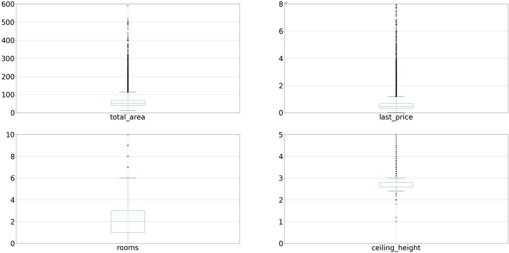

```python
# У гистограмм длинные "тонкие хвосты" мешающие анализу, поэтому определим выбросы по каждой из колонок,
# чтобы отcеч в последующем выборосы
rows = 2
columns = 2
fig, axes = plt.subplots(rows, columns, figsize=(50,25))
column_list = ['total_area', 'last_price', 'rooms', 'ceiling_height']
ylims = [600, 80000000, 10, 5]
count = 0
for row in range(rows):
    for column in range(columns):
        ax = data.boxplot(column=column_list[count], ax=axes[row,column], fontsize=40)
        ax.set_ylim([0, ylims[count]])
        count += 1
```

**Вывод** по каждой из переменных есть выбросы, отсечём их, что бы гистограммы были более наглядными

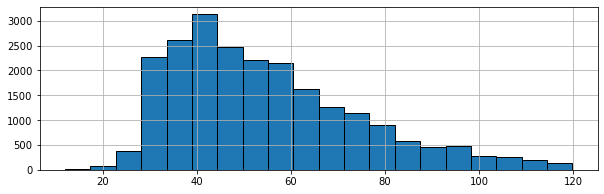

```python
# Отбросим квартиры площадью более 120 кв. м.
data.query('total_area<120')['total_area'].hist(bins=20, figsize=(10,3), ec='black')
```

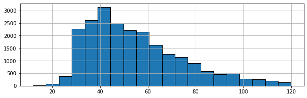

```python
# Код ревьюера

data.query('total_area<120')['total_area'].hist(bins=20, figsize=(10,3), ec='black')
None
```

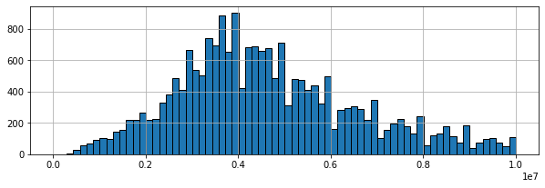

```python
# Отбросим квартиры ценой более 10 млн руб., отборсть нужно в сченой примерно в 5 млн, но посмотрим шире
data.query('last_price<10000000')['last_price'].hist(bins=70, figsize=(10,3), ec='black')
```

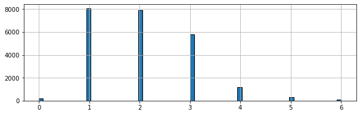

```python
# Отбросим квартиры с числом комнам больше 6
data.query('rooms<=6')['rooms'].hist(bins=70, figsize=(10,3), ec='black')
```

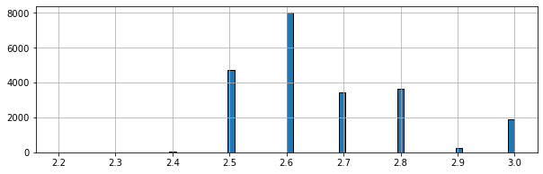

```python
# Отбросим квартиры с высотой полоков меньше 2 метров и больше 3 метров
data.query('2<ceiling_height<=3')['ceiling_height'].hist(bins=70, figsize=(10,3), ec='black')
```

**Вывод:**

### Изучение времени продажи квартиры

```python
data['days_exposition'].describe().to_frame()
```

|  | days_exposition |
| --- | --- |
| count | 20507.000000 |
| mean | 180.938363 |
| std | 219.770868 |
| min | 1.000000 |
| 25% | 45.000000 |
| 50% | 95.000000 |
| 75% | 232.000000 |
| max | 1580.000000 |

**Вывод** Из описательной статистики мы видим, что:

- Медианное число дней времени продажи квартир - 95 дней
- Среднее число дней времени продажи квартир - 180 дней
- Минимальное - 1 день
- Максимальное 1580 дней, т.е. 4 года 4 месяца (примерно) - вероятно это обьявления которые не сняли с публикации после продажи квартиры
- Четверть квартир продаётся в течении 45 дней

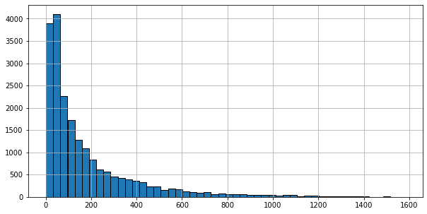

```python
data['days_exposition'].hist(bins=50, figsize=(10,5), ec='black')
```

**Вывод** Значительная часть квартир продается в первые 45 дней, после чего чего число продаж резко обрывается и в последующем медленно сокращется (распеределние Пауссона)

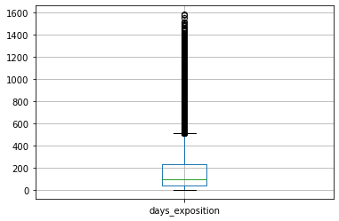

```python
data.boxplot(column='days_exposition')# Видим длинный хвост из выбросов, начинабщихся примерно от 500 дней
```

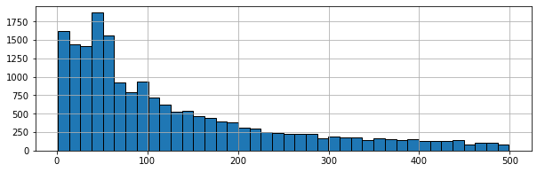

```python
#Отсечём срок продажи 500 днями, чтоб убрать выбросы. Посмотрим на данные детально
data.query('days_exposition<500')['days_exposition'].hist(bins=40, figsize=(10,3), ec='black')
```

Выделился интересный пик примерно в районе 40-70 дней с начала продажи, посмотрим его детальнее сделав срез

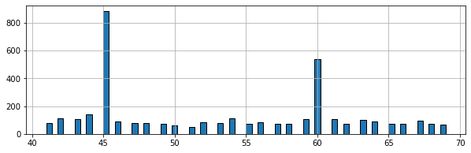

```python
data.query('40<days_exposition<70')['days_exposition'].hist(bins=70, figsize=(10,3), ec='black')
```

**Вывод** Всплек продаж на 45-й и 60-й дни, то есть примерно через 2 недели.  
**Гипотеза** Возможно с переодичностью в 15 дней агенста по продаже недвижимости обновляют свою витрину и снимают с продажи объекты по которым нашлись покупатели. проверим гипотезу расширив диапазон на 15 днек в каждую из сторон шкалы времени.

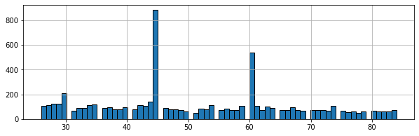

```python
data.query('25<days_exposition<85')['days_exposition'].hist(bins=70, figsize=(10,3), ec='black')
```

### Удаление редких и выбивающиеся значений

```python
#data.describe() # Чтобы видеть как было
```

Выбросы - редкие и выбивающиеся значения, будем удалять на основе межквартильного метода.  
Хорошей статистикой для суммирования выборки распределений данных является метрика Interquartile Range (IQR). IQR рассчитывается как разница между 75-м и 25-м процентилями данных - IQR определяет средние 50% данных.  
Мы расчитаем 1 и 3 квартили набора данных. Затем расчитаем IQR как разницу между 1 и 3 квартилями. Затем расчитаем пороговое значение для выбросов как 1,5-кратное IQR и вычтем это пороговое значение из 25-го процентиля и добавить его к 75-му процентилю, чтобы получить фактические пределы данных. Затем мы можем использовать эти пределы для определения значений выбросов и их удаления.

```python
def quartile_range(df, column):
    q1 = df[column].quantile(0.25)
    q3 = df[column].quantile(0.75)
    iqr = q3 - q1
    dfq = df.loc[(df[column] < q3 + 1.5*iqr) & (df[column] > q1 - 1.5*iqr), column]
    return dfq
#Столбцы с выбросами
list_features = ['last_price', 'total_area', 'kitchen_area', 'living_area', 'days_exposition', 'ceiling_height', 'rooms']
for col in list_features:
    data[col] = quartile_range(data, col)

#Изучаем, есть ли выбивающиеся значения
data.describe()
```

|  | total_images | last_price | total_area | rooms | ceiling_height | floors_total | living_area | floor | kitchen_area | balcony | airports_nearest | city_centers_nearest | parks_around3000 | parks_nearest | ponds_around3000 | ponds_nearest | days_exposition | m2_price | year | living_area_part | kitchen_area_part |
| --- | --- | --- | --- | --- | --- | --- | --- | --- | --- | --- | --- | --- | --- | --- | --- | --- | --- | --- | --- | --- | --- |
| count | 23687.000000 | 2.162700e+04 | 22444.000000 | 23492.000000 | 21946.000000 | 23602.000000 | 21014.000000 | 23687.000000 | 20213.000000 | 23687.000000 | 23687.000000 | 23687.000000 | 18177.000000 | 8079.000000 | 18177.000000 | 9109.000000 | 18838.000000 | 2.368700e+04 | 23687.000000 | 21787.000000 | 21412.000000 |
| mean | 9.860768 | 4.840263e+06 | 54.347028 | 2.030180 | 2.664750 | 10.675875 | 31.549543 | 5.894035 | 9.503889 | 0.591126 | 28377.596445 | 28377.596445 | 0.611542 | 490.804555 | 0.770314 | 518.005270 | 128.777577 | 9.943831e+04 | 2017.367079 | 0.564759 | 0.187298 |
| std | 5.682599 | 2.217651e+06 | 19.367864 | 0.973743 | 0.144745 | 6.597486 | 13.940270 | 4.885794 | 3.124930 | 0.959429 | 11174.787492 | 11174.787492 | 0.802111 | 342.317995 | 0.938352 | 277.726147 | 121.551789 | 5.031258e+04 | 1.039928 | 0.105428 | 0.073058 |
| min | 0.000000 | 1.219000e+04 | 12.000000 | 0.000000 | 2.400000 | 1.000000 | 2.000000 | 1.000000 | 1.300000 | 0.000000 | 0.000000 | 0.000000 | 0.000000 | 1.000000 | 0.000000 | 13.000000 | 1.000000 | 1.118000e+02 | 2014.000000 | 0.020000 | 0.030000 |
| 25% | 6.000000 | 3.300000e+06 | 39.400000 | 1.000000 | 2.600000 | 5.000000 | 18.400000 | 2.000000 | 7.000000 | 0.000000 | 21176.000000 | 21176.000000 | 0.000000 | 288.000000 | 0.000000 | 294.000000 | 41.000000 | 7.664940e+04 | 2017.000000 | 0.500000 | 0.130000 |
| 50% | 9.000000 | 4.400000e+06 | 50.100000 | 2.000000 | 2.600000 | 9.000000 | 30.000000 | 4.000000 | 9.000000 | 0.000000 | 26726.000000 | 26726.000000 | 0.000000 | 455.000000 | 1.000000 | 502.000000 | 85.000000 | 9.500000e+04 | 2017.000000 | 0.570000 | 0.170000 |
| 75% | 14.000000 | 6.000000e+06 | 65.600000 | 3.000000 | 2.800000 | 16.000000 | 41.000000 | 8.000000 | 11.100000 | 1.000000 | 34506.000000 | 34506.000000 | 1.000000 | 612.000000 | 1.000000 | 729.000000 | 183.000000 | 1.142857e+05 | 2018.000000 | 0.640000 | 0.230000 |
| max | 50.000000 | 1.189440e+07 | 114.400000 | 5.000000 | 3.000000 | 60.000000 | 77.800000 | 33.000000 | 19.400000 | 5.000000 | 84869.000000 | 84869.000000 | 3.000000 | 3190.000000 | 3.000000 | 1344.000000 | 512.000000 | 1.907500e+06 | 2019.000000 | 1.000000 | 0.790000 |

### Анализ факторов влияющих на цену квартиры

#### Автоматизация процесса

Для автоматизации анализа напишем функцию, которая будет смотреть зависмость переменных и выводить в графическом виде

```python
def impact_analysis(df, column):
    title_dict = {'total_area': 'Зависимость цены от площади','rooms': 'Зависимость цены от количества комнат', 'floor_level': 'Зависимость цены от этажа',
                  'category': 'Зависимость цены от удаленности от центра города',
                  'weekday':'Медиана цен по дням недели', 'month': 'Медиана цен по месяцам',
                  'year': 'Медиана цен по годам',
                  'city_centers_km': 'Зависимость цены от удаленности от центра города'}
    plt.style.use('seaborn-pastel')

    if column == 'floor_level' or column == 'category':
        sort_key = 'last_price'
    else:
        sort_key = column
    if column == 'category':
        fontsize = 10
    else:
        fontsize = 10
    df_filtered = df.groupby(column).median()['last_price'].reset_index().sort_values(by=sort_key)
    plot = df_filtered.plot(x=column, y="last_price", kind='bar', ec='black',
                            title=title_dict[column], legend=None,
                            fontsize=fontsize, figsize=(20,4))
    ax2 = plt.gca()  # удалим xlabel - у нас и так есть многоговорящее название графика
    x_axis = ax2.xaxis
    if column != 'city_centers_km':
        plt.xticks(rotation=90)

    return plot
```

#### Зависимость цены от площади

```python
#impact_analysis(data, 'total_area') # Применим функцию
#Закомментил так как при обработке компьютер подвисает
```

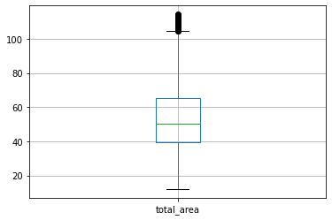

```python
data.boxplot(column='total_area') # Посмотрим выбросы чтобы их исключить
```

```python
#impact_analysis(data.query('total_area <= 70'), 'total_area') # Обросим всё что больше 70 метров - третего квартиля
#Закомментил так как при обработке компьютер подвисает
```

#### Зависимость цены от количества комнат

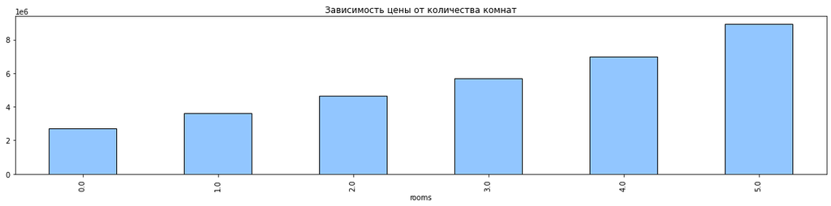

```python
impact_analysis(data, 'rooms') # Применим функцию
```

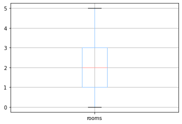

```python
data.boxplot(column='rooms') # Посмотрим выбросы чтобы их исключить
```

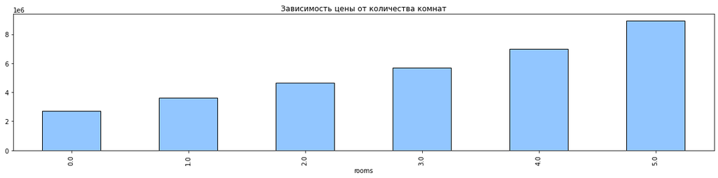

```python
impact_analysis(data.query('rooms <= 6'), 'rooms') # Обросим всё что больше 6 комнат - третего квартиля
```

**Вывод** Чем больше комнат - тем больше цена, положительная корреляция позателей.

#### Зависимость цены от удалённости от центра

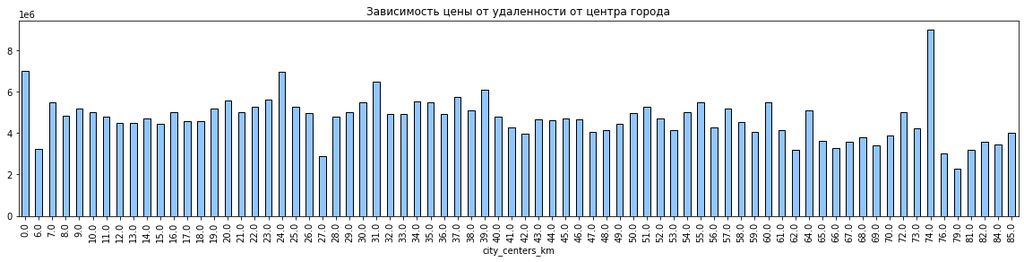

```python
# Создаим колонку city_centers_km и посчитаем для каждого объекта расстояние до центра в километрах
data['city_centers_km'] = (data.loc[:, 'city_centers_nearest']/1000).round()
impact_analysis(data, 'city_centers_km') # Применим функцию
```

```python
data['city_centers_km'].describe().to_frame()
#data.boxplot(column='city_centers_km') # Посмотрим выбросы чтобы их исключить
```

|  | city_centers_km |
| --- | --- |
| count | 23687.000000 |
| mean | 28.446025 |
| std | 11.170058 |
| min | 0.000000 |
| 25% | 21.000000 |
| 50% | 27.000000 |
| 75% | 35.000000 |
| max | 85.000000 |

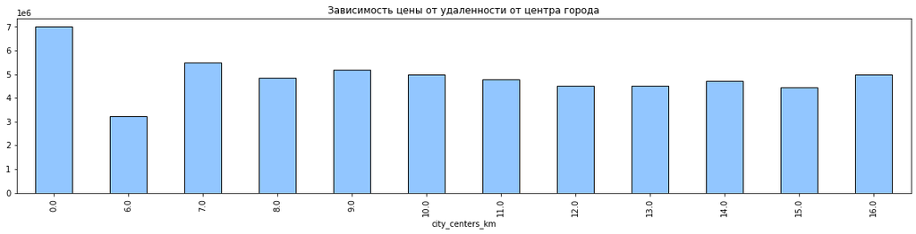

```python
impact_analysis(data.query('city_centers_km <= 16'), 'city_centers_km') # Обросим всё что больше 16 км. - третего квартиля
```

#### Зависимость цены от этажа

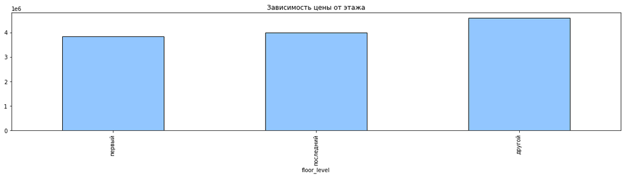

```python
impact_analysis(data, 'floor_level') # Применим функцию
```

**Вывод** Цены на квартиры не на первом и не на последнем этажах - дороже, чем на первом и последнем. Квартиры на первом этаже - дешевле всех.

#### Зависимость цены от даты размещения

```python
def placement_price(df, ylims=None):
    dmy_to_plot = ['weekday', 'month', 'year']
    titles = ['Медиана цен по дню недели', 'Медиана цен по месяцу', 'Медиана цен по году']

    for i in range(len(dmy_to_plot)):
        df_to_plot = data.groupby(dmy_to_plot[i]).median()['last_price'].reset_index().sort_values(by=dmy_to_plot[i])
        if ylims is None:
            plot = df_to_plot.plot(x=dmy_to_plot[i], y="last_price", kind='bar', figsize=(10,5), ec='black',
                                   legend=False, title=titles[i], fontsize=15)
        else:
            plot = df_to_plot.plot(x=dmy_to_plot[i], y="last_price", kind='bar', figsize=(10,5), ec='black',
                               legend=False, title=titles[i], fontsize=15, ylim=ylims[i])
        ax2 = plt.gca()
        x_axis = ax2.xaxis
        x_axis.label.set_visible(False)
        if dmy_to_plot[i] != 'weekday':
            plt.xticks(rotation=90)
    return plot
```

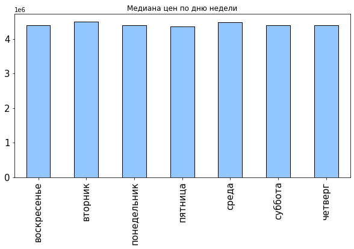

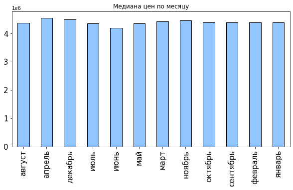

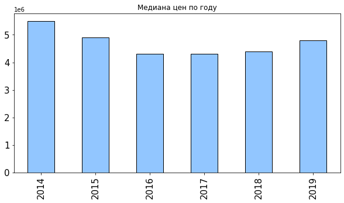

```python
placement_price(data)
```

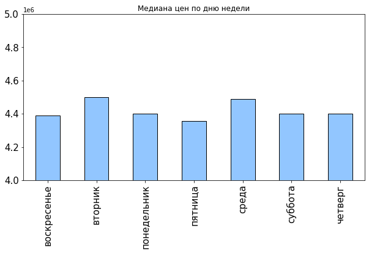

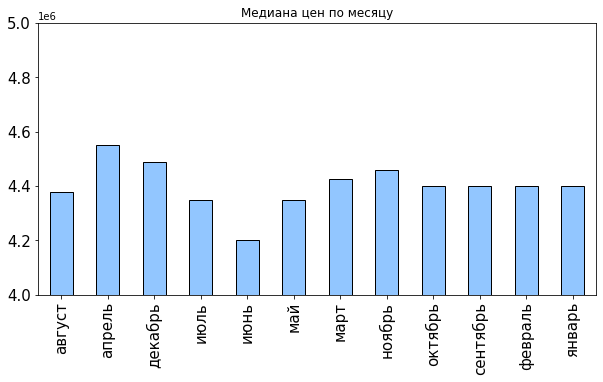

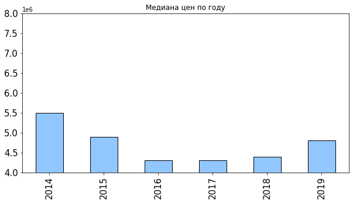

```python
# Масштаб графиков не даёт чётко увидить тенденции, заметим, что цен ниже 4 млн нет
# увеличим масстаб каждого графика по вертикали,
# ограничим каждый график по оси Y  интервалом значений 4 - 5 млн руб. для дня недели и месяца и 4 - 8 млн руб. для года
placement_price(df=data, ylims=[(4000000, 5000000), (4000000, 5000000), (4000000, 8000000)])
```

**Выводы:**

1. цена от дня недели публикации практически никак не зависит. Но, средняя цена обьявлений опубликованных в будни чуть выше чем у опубликованных в конце рабочей недели и выходные.
2. зависимость цены от месяца публикации - самые сысокие цены у опубликованных в апреле, самые низкие - в июне.
3. зависимость цены от года публикации. Выделяется 2014 год - присоеденение крыма, санкции - население вкладывает деньги в ценные активы - недвижимость. Растёт спрос - растут цены. В 2015 году - ажиотаж постепенно утихает. В 2019 году - начало пандемии COVID-19, ралли на нефтяном рынке - растёт спрос на недвижимость. В 2020-2021 годах, если бы были данные, был бы скачёк - рынок дополнительно разогрела льготная ипотека.

### Топ-10 населённых пунктов с наибольшим числом объявлений, средня, низкая и высокая цена в них

```python
#Составим топ-10 городов по чилу обьявлений
top_10 = data['locality_name'].value_counts().index.tolist()[:10]
display(top_10)
```

```
['Санкт-Петербург',
 'посeлок Мурино',
 'посeлок Шушары',
 'Всеволожск',
 'Пушкин',
 'Колпино',
 'посeлок Парголово',
 'Гатчина',
 'деревня Кудрово',
 'Выборг']
```

```python
# Посчитаем среднюю цену кв.метра и среднюю стоимоть квартиры в них, отсоритруем города по убыванию средней цены за кв. метр
mean_metrics = [data[data['locality_name'] == city]['m2_price'].median() for city in top_10]
mean_prices = [data[data['locality_name'] == city]['last_price'].median() for city in top_10]
frame = {'Город': top_10, 'Средняя цена за кв.м., руб.': mean_metrics, 'Средняя цена за квартиру, тыс. руб.': mean_prices}
dataframe = pd.DataFrame(frame).sort_values(by='Средняя цена за кв.м., руб.', ascending=False)
display(dataframe)
```

|  | Город | Средняя цена за кв.м., руб. | Средняя цена за квартиру, тыс. руб. |
| --- | --- | --- | --- |
| 0 | Санкт-Петербург | 104755.95 | 5150000.0 |
| 4 | Пушкин | 100000.00 | 4970000.0 |
| 8 | деревня Кудрово | 91860.50 | 3785000.0 |
| 6 | посeлок Парголово | 91642.90 | 4100000.0 |
| 1 | посeлок Мурино | 85890.20 | 3400000.0 |
| 2 | посeлок Шушары | 76876.20 | 3950000.0 |
| 5 | Колпино | 74723.75 | 3600000.0 |
| 7 | Гатчина | 67796.60 | 3090000.0 |
| 3 | Всеволожск | 65789.50 | 3450000.0 |
| 9 | Выборг | 58158.30 | 2873500.0 |

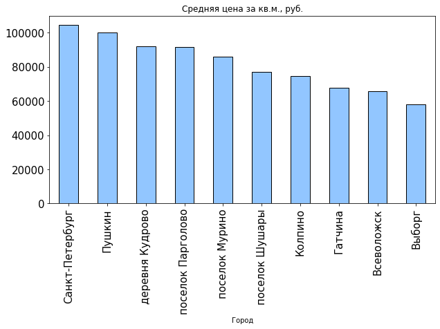

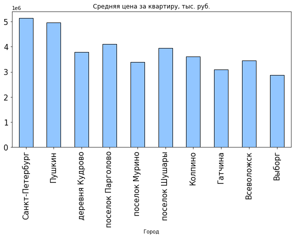

```python
dataframe.plot(x='Город', y='Средняя цена за кв.м., руб.', kind='bar', figsize=(10,5), ec='black',
                               legend=False, title='Средняя цена за кв.м., руб.', fontsize=15)
dataframe.plot(x='Город', y='Средняя цена за квартиру, тыс. руб.', kind='bar', figsize=(10,5), ec='black',
                               legend=False, title='Средняя цена за квартиру, тыс. руб.', fontsize=15)
```

### Зависимоть цены от удалённости от центра

```python
# Создадим срез наблюдений с локацией в Санкт-Петербурге
# Добавим колонку с расстонием до центра в километрах и округлим его до километра
data_spb = data.query('locality_name == "Санкт-Петербург"')
data_spb['city_centers_km'] = (data_spb.loc[:, 'city_centers_nearest']/1000).round()
#data_spb.info()
#data_spb.head()
```

```python
# Код ревьюера

# Вот пример на массивах, но с df похожая ситуация может произойти
list_1 = [1, 2, 3]
list_2 = list_1
list_2[0] = 4

print('По идее list_1 не должен меняться, но list_1 =', list_1)

list_1 = [1, 2, 3]
list_2 = list_1.copy()
list_2[0] = 4

print('list_1 не изменился, list_1 =', list_1)
```

```
По идее list_1 не должен меняться, но list_1 = [4, 2, 3]
list_1 не изменился, list_1 = [1, 2, 3]
```

```python
# Посчтиаем средную цену квадратного метра для каждого из километров
# Сождадаим датафрейм с каилметрами и ценами, осортурем по возрастнию числа километров
mean_prices_spb = [data_spb[data_spb['city_centers_km'] == i]['m2_price'].median() for i in data_spb['city_centers_km']]
frame = {'Километр': data_spb['city_centers_km'],'Средняя цена кв.м.': mean_prices_spb}
dataframe = pd.DataFrame(frame).sort_values(by='Километр', ascending=True)
```

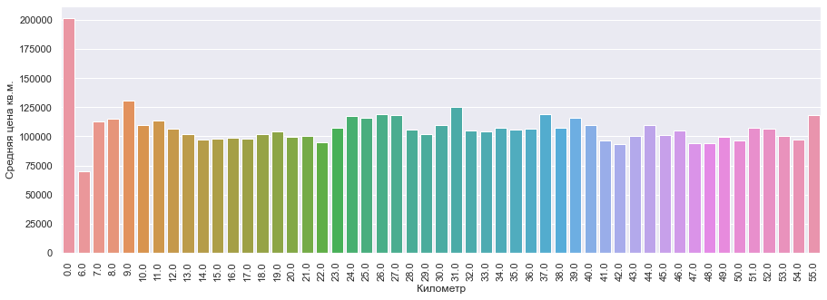

```python
# Для того чтобы построить график с ценами в разрезе километров воспользуемся библиотекой Seaborn
# (импорт библиотеки перенёс в начало ноутбука, в ячеку с импортами)
# Постром столбчатую диаграмму
sns.set(rc={'figure.figsize':(15,5)})# зададим размеры графика
plt.xticks(rotation=90)
sns.barplot(data=dataframe, x='Километр', y='Средняя цена кв.м.')
```

**Выводы:**

```python
data_spb.query('city_centers_km > 18').sort_values(by='city_centers_km', ascending=False)
```

|  | total_images | last_price | total_area | first_day_exposition | rooms | ceiling_height | floors_total | living_area | floor | is_apartment | studio | open_plan | kitchen_area | balcony | locality_name | airports_nearest | city_centers_nearest | parks_around3000 | parks_nearest | ponds_around3000 | ponds_nearest | days_exposition | m2_price | year | month | weekday | floor_level | living_area_part | kitchen_area_part | … |
| --- | --- | --- | --- | --- | --- | --- | --- | --- | --- | --- | --- | --- | --- | --- | --- | --- | --- | --- | --- | --- | --- | --- | --- | --- | --- | --- | --- | --- | --- | --- |
| 13783 | 14 | 3950000.0 | 30.0 | 2017-11-08 | 1.0 | 3.0 | 7.0 | 11.3 | 6 | NaN | False | False | 10.3 | 0 | Санкт-Петербург | 54723 | 54723 | 1.0 | 434.0 | 1.0 | 429.0 | 197.0 | 131666.7 | 2017 | ноябрь | среда | другой | 0.38 | 0.34 | … |
| 7460 | 18 | 8000000.0 | 40.0 | 2018-07-22 | 1.0 | 3.0 | 7.0 | 10.0 | 6 | NaN | False | False | NaN | 0 | Санкт-Петербург | 54723 | 54723 | 1.0 | 434.0 | 1.0 | 429.0 | 60.0 | 200000.0 | 2018 | июль | воскресенье | другой | 0.25 | 0.50 | … |
| 10977 | 10 | 5750000.0 | 44.5 | 2017-12-03 | 1.0 | 2.8 | 25.0 | 17.0 | 24 | NaN | False | False | 14.3 | 1 | Санкт-Петербург | 54784 | 54784 | 1.0 | 350.0 | 1.0 | 343.0 | 67.0 | 129213.5 | 2017 | декабрь | воскресенье | другой | 0.38 | 0.32 | … |
| 9948 | 6 | 4450000.0 | 43.4 | 2017-09-11 | 1.0 | 2.8 | 7.0 | 15.7 | 5 | NaN | False | False | 14.6 | 0 | Санкт-Петербург | 54723 | 54723 | 1.0 | 434.0 | 1.0 | 429.0 | 45.0 | 102534.6 | 2017 | сентябрь | понедельник | другой | 0.36 | 0.34 | … |
| 7518 | 4 | 6600000.0 | 57.9 | 2017-11-19 | 2.0 | 3.0 | 7.0 | 36.4 | 2 | NaN | False | False | 10.6 | 2 | Санкт-Петербург | 54723 | 54723 | 1.0 | 434.0 | 1.0 | 429.0 | 20.0 | 113989.6 | 2017 | ноябрь | воскресенье | другой | 0.63 | 0.18 | … |
| ... | ... | ... | ... | ... | ... | ... | ... | ... | ... | ... | ... | ... | ... | ... | ... | ... | ... | ... | ... | ... | ... | ... | ... | ... | ... | ... | ... | ... | ... | … |
| 17202 | 20 | 3300000.0 | 33.0 | 2019-04-14 | 1.0 | 2.6 | 15.0 | 18.0 | 9 | NaN | False | False | 7.0 | 2 | Санкт-Петербург | 18660 | 18660 | 1.0 | 283.0 | 1.0 | 48.0 | NaN | 100000.0 | 2019 | апрель | воскресенье | другой | 0.55 | 0.21 | … |
| 17230 | 2 | NaN | NaN | 2017-12-06 | 5.0 | 2.7 | 16.0 | NaN | 1 | NaN | False | False | NaN | 0 | Санкт-Петербург | 18863 | 18863 | 1.0 | 482.0 | 2.0 | 755.0 | 11.0 | 110000.0 | 2017 | декабрь | среда | первый | NaN | NaN | … |
| 17233 | 11 | 4300000.0 | 42.0 | 2018-03-30 | 1.0 | 2.7 | 16.0 | 24.2 | 14 | NaN | False | False | 9.1 | 2 | Санкт-Петербург | 18551 | 18551 | 0.0 | NaN | 0.0 | NaN | 63.0 | 102381.0 | 2018 | март | пятница | другой | 0.58 | 0.22 | … |
| 2440 | 17 | 9690000.0 | 60.6 | 2017-12-21 | 2.0 | 2.8 | 23.0 | 29.0 | 22 | NaN | False | False | 10.4 | 2 | Санкт-Петербург | 18695 | 18695 | 1.0 | 51.0 | 1.0 | 344.0 | NaN | 159901.0 | 2017 | декабрь | четверг | другой | 0.48 | 0.17 | … |
| 0 | 20 | NaN | 108.0 | 2019-03-07 | 3.0 | 2.7 | 16.0 | 51.0 | 8 | NaN | False | False | NaN | 0 | Санкт-Петербург | 18863 | 18863 | 1.0 | 482.0 | 2.0 | 755.0 | NaN | 120370.4 | 2019 | март | четверг | другой | 0.47 | 0.23 | … |

11873 rows × 30 columns

### Анализ предложений в центре

```python
#Сделаем срез предложений расположенных в 8 километровой зоне от центра СПб
data_spb_center = data_spb.query('city_centers_nearest <= 8000')
print('В центре Санкт-Петербурга ', len(data_spb_center), ' предложений(-я) квартир ')
```

```
В центре Санкт-Петербурга  123  предложений(-я) квартир
```

#### Изучение параметров площадь, цена, число комнат, высота потолков

```python
data_spb_center[['total_area', 'last_price', 'rooms', 'ceiling_height']].describe()
```

|  | total_area | last_price | rooms | ceiling_height |
| --- | --- | --- | --- | --- |
| count | 123.000000 | 1.220000e+02 | 123.000000 | 121.000000 |
| mean | 51.791870 | 5.781876e+06 | 1.707317 | 2.709917 |
| std | 16.444405 | 1.919327e+06 | 0.732520 | 0.126758 |
| min | 24.000000 | 2.268000e+06 | 0.000000 | 2.500000 |
| 25% | 39.300000 | 4.300000e+06 | 1.000000 | 2.600000 |
| 50% | 52.500000 | 5.295000e+06 | 2.000000 | 2.700000 |
| 75% | 60.100000 | 6.885000e+06 | 2.000000 | 2.800000 |
| max | 96.600000 | 1.100000e+07 | 3.000000 | 3.000000 |

**Вывод** Описательная статистика показала, что:

- Есть квартиры площадью от 24 до 96,6 кв.м. Средняя площаль - 51 кв. м., медианная - 52 кв. м. (не влияют крайние значения).
- Цена колеблется от 2,2 млн. до 11 млн руб., средняя цена - 5,8 млн руб., медианная - 5,2 млн руб. На помощь пришёл https://matematika-club.ru/e-in-number
- Число комнат от 0 (это студии или пропуски) до 3 комнат. Среднее число комнат 1,7, медианное - 2.
- Высота потолков от 2,5 до 3 метров, но средняя 2,7 м., медианная - 2,7 м., что соответвует реальности в целом.

```python
#data_spb_center['total_area'].hist(bins=20, figsize=(10,5), ec='black') # построим гистограмму для колонки
```

```python
#data_spb_center['last_price'].hist(bins=20, figsize=(10,5), ec='black') # построим гистограмму для колонки
```

```python
#data_spb_center['rooms'].hist(bins=20, figsize=(10,5), ec='black') # построим гистограмму для колонки
```

```python
#data_spb_center['ceiling_height'].hist(bins=20, figsize=(10,5), ec='black') # построим гистограмму для колонки
```

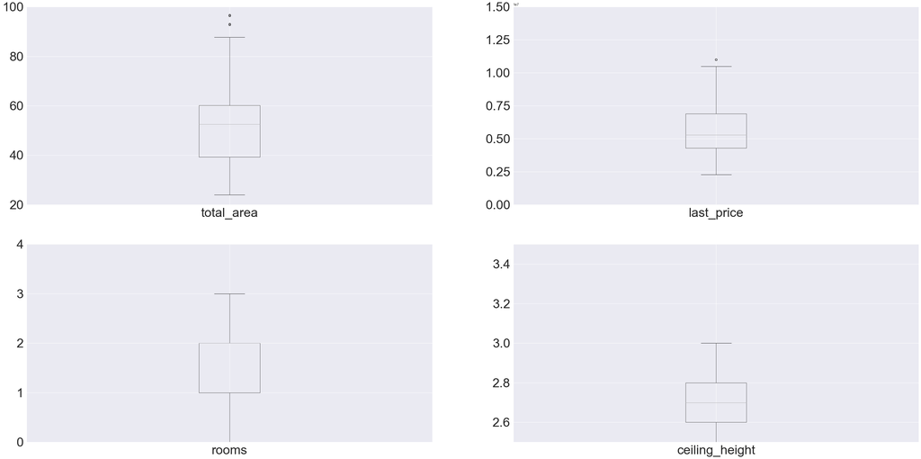

```python
# Определим выбросы по каждой из колонок, чтобы отcеч в последующем выборосы
rows = 2
columns = 2
fig, axes = plt.subplots(rows, columns, figsize=(50,25))
column_list = ['total_area', 'last_price', 'rooms', 'ceiling_height']
ylims = [100, 15000000, 4, 3.5]
ylims_zero = [20, 0, 0, 2.5]
count = 0
for row in range(rows):
    for column in range(columns):
        ax = data_spb_center.boxplot(column=column_list[count], ax=axes[row,column], fontsize=40)
        ax.set_ylim([ylims_zero[count], ylims[count]])
        count += 1
```

**Выводы:**

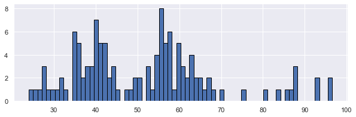

```python
# Отбросим квартиры площадью более 120 кв. м.
data_spb_center.query('total_area<120')['total_area'].hist(bins=70, figsize=(10,3), ec='black')
```

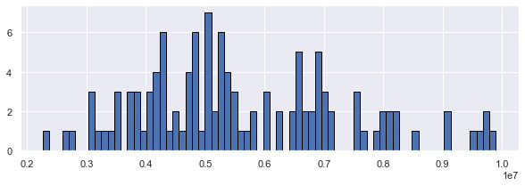

```python
# Отбросим квартиры ценой более 10 млн руб., отборсть нужно в отсечкой примерно в 5 млн, но посмотрим шире
data_spb_center.query('last_price<10000000')['last_price'].hist(bins=70, figsize=(10,3), ec='black')
```

**Вывод** Цены в среднем стремятся к 5 млн рублей.

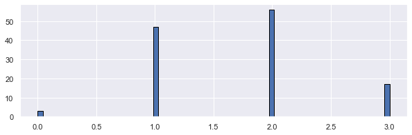

```python
# Отбросим квартиры с числом комнам больше 6
data_spb_center.query('rooms<=6')['rooms'].hist(bins=70, figsize=(10,3), ec='black')
```

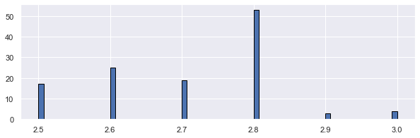

```python
# Отбросим квартиры с высотой полоков меньше 2 метров и больше 3 метров
data_spb_center.query('2<ceiling_height<=3')['ceiling_height'].hist(bins=70, figsize=(10,3), ec='black')
```